# An Ideal Pipeline

# Step 0: Complete documentation

# Step 1: ML research problem definition

### 1.1 Define the problems & goals.

To build classifiers for predicting human acute leukemia classes, only using gene expression data monitoring by DNA microarrays.

### 1.2 Ensure the problem solvable by ML.

Although we could not assess the original researchers’ experience in ML, we can work on the data aspect.  
The “Cancer Stat Facts: Leukemia” (2000) reported in 1999 (the year T. R. Golub et al. (1999) published this paper), the observed rate for leukemia was 12.5 per 100,000 people (that is, about 12,500 people). According to Barlett, Kotrlik, and Higgins (2001), the minimum sample size (to get statistically meaningful result) for such population was 370.

### 1.3 Set evaluation metrics and success criteria.

Since this is a binary classification problem, one can also use the following metrics as needed: confusion matrix, specificity, recall(sensitivity), precision, and ROC-AUC curve. We used confusion matrices to visualize the details of misclassified cases.

Salah et al. (2019) suggest that classifiers designed for this task should achieve at least 90% accuracy to be considered successful.

### 1.4 Hypotheses registration

We have registered the following three hypotheses in the project Github [repository](https://github.com/Machine-Learning-Pipelines/IdealMachineLearningPipeline) as an example:

1, Common binary classification algorithms can achieve high accuracy in this type of leukemia cancer classification problem (i.e., no need to create/invent an algorithm from scratch).

2, The original classifier selected 50 features (too many). Whether using Golub’s original classifier or other common binary classification algorithms, one may use fewer features (such as 10, or 6 features) to achieve similar model performances.

3, The most “informative” genes selected by Golub’s method, may not be the same as the important features selected by common binary classification algorithms, for example, the list of feature importance with random forest algorithms.

### 1.5 Ethical concerns

First of all it should be noted that the data collected was medical data.  
Vayena, Blasimme, and Cohen (2018) emphasized the usage of medical data should comply with privacy requirements and data protection. The Golub study should address questions regarding the above two aspects, as well as questions like the data anonymization process, the access to the data before anonymization, the regional data usage regulation, etc.

```r
# https://bioconductor.org/packages/release/data/experiment/html/golubEsets.html
#if (!require("BiocManager", quietly = TRUE)) install.packages("BiocManager")

#BiocManager::install("golubEsets")

require(golubEsets)  # data

require(rlang)  # hash
require(factoextra)  # pca
# model
require(e1071)
require(MASS)
require(sparsediscrim)
require(randomForest)
```

# Step 2: Input data

### 2.1 Collect appropriate data

In step 1, we recognized a faulty generalization and identified that the existing sample size was not enough. The next step is to check if more data from the same source is available (the same hospitals or institutes, where the samples were collected using the same method). If possible, increase the sample size to reach a minimum sample size of n = 370.

To avoid faulty generalization fallacy, one should check if similar data on other types of cancer is available, since acute leukemia is only one of many types of cancer. (None available)

Finally, depending on the nature of the problem and the data, check if common techniques to deal with a lack of data such as data augmentation, data generation/simulation, and data imputation are applicable in this case. (None applicable)

Apart from statistical heuristics, it is necessary to acknowledge that special cases may exist depending on the fields. According to domain experts’ experience, Mukherjee et al. (2003) believed a “10-20 samples range” would be enough for such classification problems; Dobbin, Zhao, and Simon (2008) even claimed the Golub study had a “large” sample size.

### 2.2 Load the data

We used the data from the R package **golubEsets** by T. Golub (2023) for reproduction.  
First, load the package and extract the (part of) data we need in R.  
Then, check if the data format is suitable for subsequent processing (It is in matrix format).  
Lastly, check if the data contents, dimensions, and data types are as expected.

```r
#data(Golub_Merge)
data(Golub_Train)
golub_train_p = t(Golub_Train@assayData[["exprs"]])
golub_train_r =pData(Golub_Train)[, "ALL.AML"]

#Testing data predictor
data(Golub_Test)
golub_test_p = t(Golub_Test@assayData[["exprs"]])
golub_test_r = pData(Golub_Test)[, "ALL.AML"]

#Show summary
rbind(Train = dim(golub_train_p), Test = dim(golub_test_p))
```

```
##       [,1] [,2]
## Train   38 7129
## Test    34 7129
```

```r
cbind(Train = table(golub_train_r),Test = table(golub_test_r))
```

```
##     Train Test
## ALL    27   20
## AML    11   14
```

```r
# combine covariates into a df
df_cov = data.frame(Golub_Train$BM.PB, Golub_Train$T.B.cell, Golub_Train$FAB, Golub_Train$Date, Golub_Train$Gender, Golub_Train$pctBlasts, Golub_Train$Treatment)

df_test_cov = data.frame(Golub_Test$BM.PB, Golub_Test$T.B.cell, Golub_Test$FAB, Golub_Test$Date, Golub_Test$Gender, Golub_Test$pctBlasts, Golub_Test$Treatment)
```

### 2.3 Preserve the data

We register the data by storing a snapshot of the cleaned and processed data (on Zenodo as an example, [id: 8123245](https://zenodo.org/record/8123245)).

Another failsafe is to save the hashes for the data file, this also ensures data integrity. Make sure to check if retrieval is successful after preservation.

```r
golub_training = cbind(golub_train_p, golub_train_r)
save(golub_training, file = "./golub_orig_trainSet.rda")
golub_hashes = hash_file("./golub_orig_trainSet.rda")
golub_hashes
```

```
## [1] "2da2e8ea937263553c7d2b3e778c58f9"
```

### 2.4 Exploratory data analysis

Besides gene data, we noticed another data set in the documentation of golubEsets package, which detailed the 11 covariates of the data samples. After preliminary check, we realized there was a severe missing data problem. Not a single data record was complete (there was always missing data for each sample). 9 out of the 11 covariates had missing values, ranging from 24% to 88%. Furthermore, the distributions of two categorical variables were not balanced between the training set and the test set; the later data set was collected at a different time (Slonim et al. 2000).  
This means, there was a representative bias in the gene data.

```r
# any rows of the data that are fully observed?
which(rowSums(is.na(df_cov))==0)
```

```
## integer(0)
```

```r
which(rowSums(is.na(df_test_cov))==0)
```

```
## integer(0)
```

```r
rbind(Train = round(prop.table(table(Golub_Train$T.B.cell, useNA = "ifany")),3), Test = round(prop.table(table(Golub_Test$T.B.cell, useNA = "ifany")),3))
```

```
##       B-cell T-cell  <NA>
## Train  0.500  0.211 0.289
## Test   0.559  0.029 0.412
```

```r
rbind(Train = round(prop.table(table(Golub_Train$FAB, useNA = "ifany")),3), Test = round(prop.table(table(Golub_Test$FAB, useNA = "ifany")),3))
```

```
##          M1    M2    M4    M5  <NA>
## Train 0.079 0.132 0.026 0.053 0.711
## Test  0.029 0.147 0.088 0.000 0.735
```

```r
rbind(Train = round(prop.table(table(Golub_Train$Gender, useNA = "ifany")),3), Test = round(prop.table(table(Golub_Test$Gender, useNA = "ifany")),3))
```

```
##           F     M  <NA>
## Train 0.211 0.395 0.395
## Test  0.441 0.324 0.235
```

```r
rbind(Train = round(prop.table(table(Golub_Train$Treatment, useNA = "ifany")),3), Test = round(prop.table(table(Golub_Test$Treatment, useNA = "ifany")),3))
```

```
##       Failure Success  <NA>
## Train   0.158   0.132 0.711
## Test    0.059   0.059 0.882
```

```r
# different categories
round(prop.table(table(Golub_Train$pctBlasts, useNA = "ifany")),3)
```

```
##
##    34    44    67    70    76    77    79    80    86    93  <NA>
## 0.026 0.026 0.026 0.026 0.026 0.053 0.026 0.026 0.026 0.026 0.711
```

```r
round(prop.table(table(Golub_Test$pctBlasts, useNA = "ifany")),3)
```

```
##
##    57    76    86    93  <NA>
## 0.029 0.029 0.029 0.029 0.882
```

```r
# these two variables don't have any NAs; could be used for re-distributing the train/test samples
cbind(Train = table(Golub_Train$BM.PB), Test = table(Golub_Test$BM.PB))
```

```
##    Train Test
## BM    38   24
## PB     0   10
```

```r
cbind(Train = table(Golub_Train$Source), Test = table(Golub_Test$Source))
```

```
##         Train Test
## CALGB      11    4
## CCG         0    5
## DFCI       27   17
## St-Jude     0    8
```

### 2.5 Ensure representativeness and minimize biases

To avoid sampling bias, one method from a statistical perspective is stratified random sampling.  
This ensures the distributions of categorical variables in the samples be roughly equal to those of the population. However, in Golub’s case, all ALL patients were children; all AML patients were adults. The test set had the same problem. Additionally, the test set also the problem of inconsistent data source: the 20 ALL cases were from childhood ALL patients at SJCRH & DFCI, but the 14 AML cases included 4 samples from adults and 10 from children at CALGB, SJCRH & CCG. There is nothing we can do now to fix this bias source.

However, we can improve the representativeness of the training data.  
To address this type of representation bias due to missing categories (of covariates) in the training data (Mehrabi et al. 2021), we moved 12 samples from the test set to the training set based on our exploratory analysis. These 12 samples belonged to categories (of covariates) unseen in the training data but present in the test set:  
5 random peripheral blood samples (feature “BM.PB”);  
3 random CCG samples and 4 random St-Jude samples (feature “Source”).  
Other features had many NAs that made redistribution difficult and uncertain.  
The new training set had 50 samples, and the new test set had 22 samples.

```r
# checked: the original sample numbers of the covariates = rownames of the large matrix (golub_train_p)

# Get idx for PB, CCG & St-J.
# Pick randomly; fix the seed
set.seed(135)
PB_idx = sample(which(as.integer(Golub_Test$BM.PB)==2), 5)
CCG_idx = sample(which(as.integer(Golub_Test$Source)==2),3)
SJ_idx = sample(which(as.integer(Golub_Test$Source)==4),4)
# merge the idx
mv_idx = sort(c(PB_idx, CCG_idx, SJ_idx))
length(unique(mv_idx))
```

```
## [1] 12
```

```r
#New train & test
golub_Ntrain_p = rbind(golub_train_p, golub_test_p[mv_idx,])
golub_Ntrain_r = c(golub_train_r, golub_test_r[mv_idx])
golub_Ntest_p = golub_test_p[-mv_idx,]
golub_Ntest_r = golub_test_r[-mv_idx]

#Show summary
rbind(Train = dim(golub_Ntrain_p), Test = dim(golub_Ntest_p))
```

```
##       [,1] [,2]
## Train   50 7129
## Test    22 7129
```

```r
cbind(Train = table(golub_Ntrain_r),Test = table(golub_Ntest_r))
```

```
##     Train Test
## ALL    32   15
## AML    18    7
```

# Step 3: Data Preparation

### 3.1 Data Preprocessing

Due to the severe incomplete documentation of data preprocessing in the Golub study, the steps below were summarized from a reproduced work by Robert Gentleman (Gentleman 2005). He received these details from communication with one of the authors, Pablo Tamayo.

Let X’s denote the expression level for a gene.

1, Thresholding:  
Set the floor of 100 and ceiling of 16,000 ($100 \leq X \leq 16000$).

2, Filtering:  
Exclusion of non-informative genes with $max/min \leq 5$ or $(max-min) \leq 500$, where max and min refer to the maximum and minimum intensities for a particular gene across the 72 mRNA samples.

3, Log Transformation:  
To reduce or remove the skewness of the gene data, apply log transformation. The math formula is $X_{log} = log_{10}(X)$.

4, Standardization:  
The features had high variances, this step converted them to standardized data representations.  
Use the mean and standard deviation in the training data to standardize the test data too. ($X_{norm} = \frac{X_{log} - mean(X_{log})}{SD(X_{log})}$)

```r
golub_filter = function(x, r = 5, d=500){
    minval = min(x)
    maxval = max(x)
    (maxval/minval>r)&&(maxval-minval>d)
}

# the idx / features for traing set *and test set*
filter = apply(golub_Ntrain_p, 2, golub_filter)
filter_idx = (1:ncol(golub_Ntrain_p))[filter]

# standardize the test set using means & sd from training set.
train_means = round(apply(golub_Ntrain_p, 2, mean),3)
train_std_dev = round(apply(golub_Ntrain_p, 2, sd),3)

data_prep = function(df, filtering, tr_means, tr_sd){
  # df: N x P, train set or test set.
  # threshold
  df[df<100]=100
  df[df>16000]=16000

  # filter
  df = df[, filtering]

  # log transformation
  df = log10(df)

  # standardize, not normalize (paper2 appendix A)
  df = scale(df, center = tr_means[filtering], scale = tr_sd[filtering])

  return(df)
}

prep_train = data_prep(golub_Ntrain_p, filter_idx, train_means, train_std_dev)
prep_test = data_prep(golub_Ntest_p, filter_idx, train_means, train_std_dev)

#save(prep_train, golub_Ntrain_r, prep_test, golub_Ntest_r, file = "./golub_prep1821.rda")

cbind(train = dim(prep_train),test = dim(prep_test))
```

```
##      train test
## [1,]    50   22
## [2,]  1821 1821
```

Note:  
the number of features became 1821 after data preprocessing.

### 3.2 Data splitting

We initially kept the training set (the data collected initially) and the test set (an independent dataset collected at a different time) as the Golub study. Then, in Step 2.5, we moved 12 samples from the test set to the training set to address representation bias.

```r
# check matrix sizes & class distribution after data splitting
rbind(Ntrain = dim(prep_train), Ntest = dim(prep_test))
```

```
##        [,1] [,2]
## Ntrain   50 1821
## Ntest    22 1821
```

```r
cbind(Ntrain = table(golub_Ntrain_r),Ntest = table(golub_Ntest_r))
```

```
##     Ntrain Ntest
## ALL     32    15
## AML     18     7
```

# Step 4: Feature Selection

### 4.1 Identify KEY features

Dobbin, Zhao, and Simon (2008) discovered that in Golub’s experiment, 6 genes achieved an accuracy of 98%, compared to the >99% accuracy with 50 genes. For comparison, we fixed the sizes of the feature sets to be 6, 10, and 50.

```r
# Neighborhood analysis

## Note 16: signal-to-noise ratio/ correlation btw a gene & a class distinction
get_p = function(train_d, train_r){
    tr_m_aml =  colMeans(train_d[train_r == "AML",])
    tr_sd_aml = apply(train_d[train_r == "AML",], 2, sd)
    tr_m_all = colMeans(train_d[train_r == "ALL",])
    tr_sd_all = apply(train_d[train_r == "ALL",], 2, sd)
    p_vec = (tr_m_aml-tr_m_all)/(tr_sd_aml+tr_sd_all)
    return(p_vec)
}

# Permutation test
nna = matrix(0, 400, ncol(prep_train))
set.seed(201702)
for(i in 1:400){
    c_star = sample(golub_Ntrain_r)
    nna[i, ] = get_p(prep_train, c_star)
}

# significance level: 1%.
nna_q = apply(nna, 2, quantile, prob = c(0.005, 0.995))
p = get_p(prep_train, golub_Ntrain_r)

#select the 1% sign lvl
index_1 = (1:ncol(prep_train))[p>=nna_q[2,] | p<=nna_q[1,]]
prep_train = prep_train[, index_1]
prep_test =prep_test[, index_1]
p = p[index_1]

train_m_aml = colMeans(prep_train[golub_Ntrain_r == "AML",])
train_m_all = colMeans(prep_train[golub_Ntrain_r =="ALL",])

cbind(train = dim(prep_train),test = dim(prep_test))
```

```
##      train test
## [1,]    50   22
## [2,]   376  376
```

```r
# 50 genes
cl_index50 = c(head(order(p), 25), head(order(p, decreasing = T), 25))
b50 = (train_m_aml[cl_index50]+train_m_all[cl_index50])/2
p_50 = p[cl_index50]

prep_train50 = prep_train[, cl_index50]
prep_test50 = prep_test[, cl_index50]
#save(prep_train50, golub_Ntrain_r, prep_test50, golub_Ntest_r,b50, p_50, file = "./golub50gene.rda")

# 10 genes
cl_index10 = c(head(order(p), 5), head(order(p, decreasing = T), 5))
b10 = (train_m_aml[cl_index10]+train_m_all[cl_index10])/2
p_10 = p[cl_index10]

prep_train10 = prep_train[, cl_index10]
prep_test10 = prep_test[, cl_index10]
#save(prep_train10, golub_Ntrain_r, prep_test10, golub_Ntest_r,b10, p_10, file = "./golub10gene.rda")

# 6 genes
cl_index6 = c(head(order(p), 3), head(order(p, decreasing = T), 3))
b6 = (train_m_aml[cl_index6]+train_m_all[cl_index6])/2
p_6 = p[cl_index6]

prep_train6 = prep_train[, cl_index6]
prep_test6 = prep_test[, cl_index6]
#save(prep_train6, golub_Ntrain_r, prep_test6, golub_Ntest_r,b6, p_6, file = "./golub6gene.rda")
```

### 4.2 Assess the impact of features

Assessments should be done for all genes selected as predictors. For example, gene “M27891 at” is described as “CST3 Cystatin C (amyloid angiopathy and cerebral hemorrhage)”, it is related to the condition of kidneys, cerebrovascular disorder and bleeding in the brain (Wang and Huang 2006).

### 4.3 Further attempts

(This section documents any exploratory or investigative attempts that are relevant to the overall analysis of the study, whether or not they yield useful or significant findings.)

For instance, we conducted Principle Components Analysis (PCA) to reduce the dimensions of gene data (Howley et al. 2005), with the aim of identifying trends, clusters, and outliers to improve interpretability.  
However, the results were not ideal, as only the first three clusters explained 65% of the variance and there were a total of 50 clusters. Therefore, we did not elaborate or build on this result.  
From Plot 2 and 3, we see there were two linearly separable clusters.

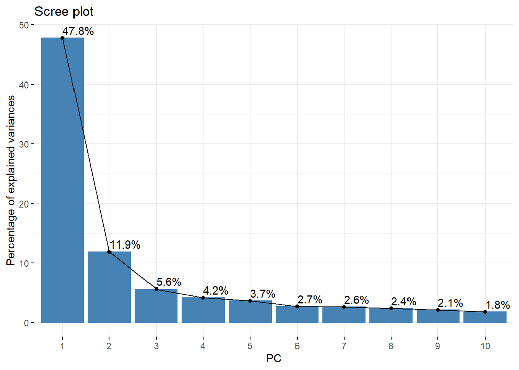

```r
# https://stats.stackexchange.com/questions/72839/how-to-use-r-prcomp-results-for-prediction
pca = prcomp(prep_train50,  scale =TRUE)
#str(pca)
#summary(pca)
fviz_screeplot(pca, addlabels=TRUE, choice = "variance",xlab="PC")
```

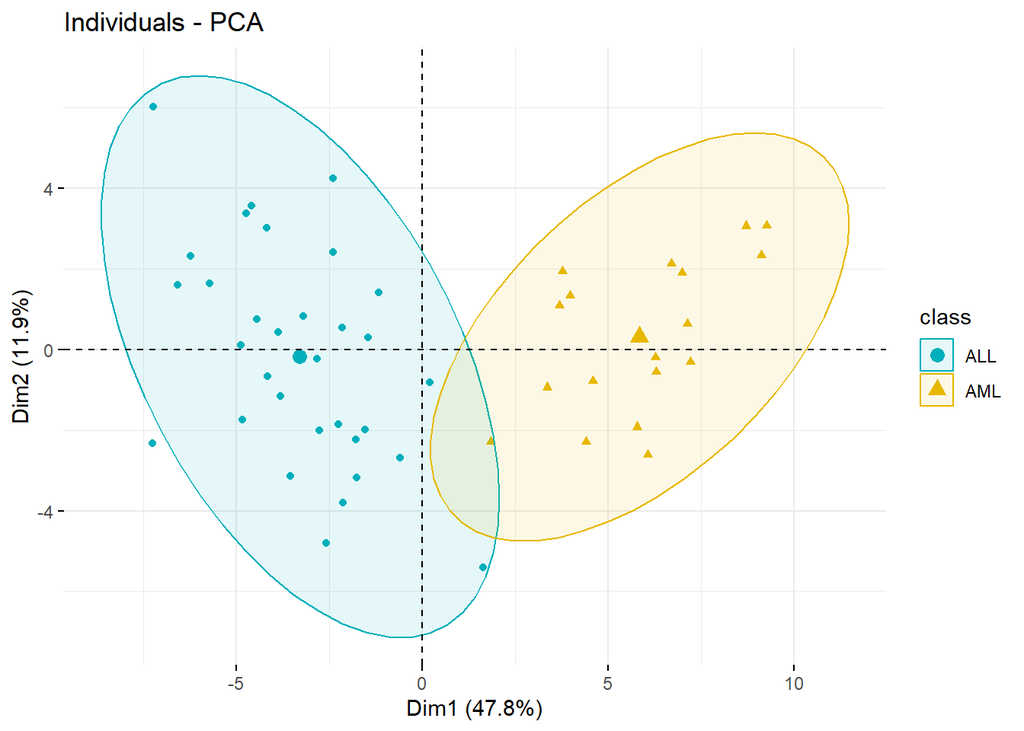

```r
# plot 2
fviz_pca_ind(pca,
             geom.ind = "point",
             col.ind = golub_Ntrain_r,
             palette = c("#00AFBB", "#E7B800"),
             addEllipses = TRUE, # Concentration ellipses
             legend.title = "class"
             )
```

[figure not shown]

```r
# plot 3
pc1 = pca$x[,1]
pc2 = pca$x[,2]
color = golub_Ntrain_r
legends = levels(golub_Ntrain_r)

plot(pc2 ~ pc1, pch=19,cex=0.8, col = color)
legend("bottomright", legend = legends, col = c("red","black"),bty="n", text.col = c("red","black"))
grid(col = "grey")
```

[figure not shown]

```r
# plot 4
pca_Ntest = predict(pca, prep_test50)
plot(pc2 ~ pc1,cex=0.8, col = color)
color2 = golub_Ntest_r
points(pca_Ntest, col = color2, pch=19)
legend("bottomright", legend = legends, col = color2,bty="n", text.col = c("red","black"))
legend("topright", legend=c("training set", "test set"), col=color2, pch=c(1, 19))
grid(col = "grey")
```

# Step 5: Model Training

Before creating an algorithm from scratch, we should explore existing statistical learning methods to see if they are applicable. In the Golub study, the “weighted gene voting scheme” proposed was a variant of diagonal Linear Discriminant Analysis (LDA) (Dudoit, Fridlyand, and Speed 2002), and the separation measure resembles the calculation of t-statistic (Li et al. 2001).  
Since this is a high-dimensional data classification problem, our analysis of algorithm choice is simplified below:

1. KNN - not efficient due to the P>>N (the number of predictors way larger than the sample size), curse of dimensionality.
2. Naive Bayes - could try, but assumptions were violated; since a large number of genes highly correlated and the genes contributed differently (T. R. Golub et al. 1999).
3. SVM & variants of discriminant function - good starting points for such task (Pappu and Pardalos 2014).
4. Tree-based methods (Random Forest) - we were interested in the feature importance.
5. Neural Networks - not practical due to the small sample sizes (Alwosheel, Cranenburgh, and Chorus 2018).

Thus, our choice of algorithms narrow down to four: Naive Bayes, SVM, D-LDA and tree-based method.

```r
# Golub's method: note 19 & 20.
vote_PS_cls = function(df_p, p_corr, b_g, true_cls){

  # the vote of gene g is Vg = a_g*(x_g-b_g)
  vote = t(p_corr*t(sweep(df_p, 2, b_g)))
  # sum up pos/neg votes
  V_win = apply(vote, 1, function(x) sum(x[x>0]))
  V_lose = abs(apply(vote, 1, function(x) sum(x[x<=0])))

  PS = (V_win - V_lose)/(V_win + V_lose)
  pred_r = ifelse(abs(PS)>0.3, ifelse(PS>0, "AML", "ALL"), "Uncertain")
  tble = table(Predict = pred_r, Actual = true_cls)
  acc = round(sum(diag(tble))/sum(tble),3)
  print(tble)
  print(paste("The accuracy is:", acc, "with", ncol(df_p), "features."))

}

vote_PS_cls(prep_train50, p_50, b50, golub_Ntrain_r)
```

```
##            Actual
## Predict     ALL AML
##   ALL        30   0
##   AML         0  18
##   Uncertain   2   0
## [1] "The accuracy is: 0.96 with 50 features."
```

```r
vote_PS_cls(prep_train10, p_10, b10, golub_Ntrain_r)
```

```
##            Actual
## Predict     ALL AML
##   ALL        30   0
##   AML         0  17
##   Uncertain   2   1
## [1] "The accuracy is: 0.94 with 10 features."
```

```r
vote_PS_cls(prep_train6,  p_6,  b6,  golub_Ntrain_r)
```

```
##            Actual
## Predict     ALL AML
##   ALL        31   0
##   AML         0  18
##   Uncertain   1   0
## [1] "The accuracy is: 0.98 with 6 features."
```

```r
# 50 genes
df50 = data.frame(prep_train50)
df50$cls = golub_Ntrain_r

df50_test = data.frame(prep_test50)
df50_test$cls = golub_Ntest_r

# 10 genes
df10 = data.frame(prep_train10)
df10$cls = golub_Ntrain_r

df10_test = data.frame(prep_test10)
df10_test$cls = golub_Ntest_r

# 6 genes
df6 = data.frame(prep_train6)
df6$cls = golub_Ntrain_r

df6_test = data.frame(prep_test6)
df6_test$cls = golub_Ntest_r
```

```r
# 50 genes
nb50 = naiveBayes(cls ~., df50)
pred50 = predict(nb50, prep_train50)
tble50 = table(Predict = pred50, Actual = df50$cls);tble50
```

```
##        Actual
## Predict ALL AML
##     ALL  32   0
##     AML   0  18
```

```r
# 10 genes
nb10 = naiveBayes(cls ~., df10)
pred10 = predict(nb10, prep_train10)
tble10 = table(Predict = pred10, Actual = df10$cls);tble10
```

```
##        Actual
## Predict ALL AML
##     ALL  32   0
##     AML   0  18
```

```r
# 6 genes
nb6 = naiveBayes(cls ~., df6)
pred6 = predict(nb6, prep_train6)
tble6 = table(Predict = pred6, Actual = df6$cls);tble6
```

```
##        Actual
## Predict ALL AML
##     ALL  32   0
##     AML   0  18
```

Note:  
Naive Bayes achieved 100% classification accuracy on the training set with 50, 10, and 6 features respectively.

```r
# linear kernel
# 50
svm50 = svm(cls ~., df50)
svm50_pred = predict(svm50, df50)
svm_tb50 = table(Predict = svm50_pred, Actual = df50$cls);svm_tb50
```

```
##        Actual
## Predict ALL AML
##     ALL  32   0
##     AML   0  18
```

```r
# 10
svm10 = svm(cls ~., df10)
svm10_pred = predict(svm10, df10)
svm_tb10 = table(Predict = svm10_pred, Actual = df10$cls);svm_tb10
```

```
##        Actual
## Predict ALL AML
##     ALL  32   0
##     AML   0  18
```

```r
# 6
svm6 = svm(cls ~., df6)
svm6_pred = predict(svm6, df6)
svm_tb6 = table(Predict = svm6_pred, Actual = df6$cls);svm_tb6
```

```
##        Actual
## Predict ALL AML
##     ALL  32   0
##     AML   0  18
```

```r
# quadratic kernel
# 50
svmq50 = svm(cls ~., df50, kernel = "polynomial", degree = 2,  gamma =0.01, coef0 = 100)
svmq50_pred = predict(svmq50, df50)
svmq_tb50 = table(Predict = svmq50_pred, Actual = df50$cls);svmq_tb50
```

```
##        Actual
## Predict ALL AML
##     ALL  32   0
##     AML   0  18
```

```r
# 10
svmq10 = svm(cls ~., df10, kernel = "polynomial", degree = 2,  gamma =0.01, coef0 = 100)
svmq10_pred = predict(svmq10, df10)
svmq_tb10 = table(Predict = svmq10_pred, Actual = df10$cls);svmq_tb10
```

```
##        Actual
## Predict ALL AML
##     ALL  32   0
##     AML   0  18
```

```r
# 6
svmq6 = svm(cls ~., df6, kernel = "polynomial", degree = 2,  gamma =0.01, coef0 = 100)
svmq6_pred = predict(svmq6, df6)
svmq_tb6 = table(Predict = svmq6_pred, Actual = df6$cls);svmq_tb6
```

```
##        Actual
## Predict ALL AML
##     ALL  32   0
##     AML   0  18
```

```r
# LDA w/ 50/10/6 features
# lda50 = lda(cls~., df50)
# Error in lda.default(x, grouping, ...) :   variables  3  8 10 20 27 38 39 46 47 appear to be constant within groups
# R could not solve the matrix inverse because the within-class covariance matrix was singular; common LDA problem when P>>N.

# DLDA -50
dlda50 = lda_diag(cls~., df50)
dlda50_pred = predict(dlda50, df50, type="class")
dlda50_tb = table(Predict =dlda50_pred, Actual = df50$cls);dlda50_tb
```

```
##        Actual
## Predict ALL AML
##     ALL  31   0
##     AML   1  18
```

```r
round(sum(diag(dlda50_tb))/sum(dlda50_tb),3)
```

```
## [1] 0.98
```

```r
# DLDA - 10
dlda10 = lda_diag(cls~., df10)
dlda10_pred = predict(dlda10, df10, type="class")
dlda10_tb = table(Predict =dlda10_pred, Actual = df10$cls);dlda10_tb
```

```
##        Actual
## Predict ALL AML
##     ALL  31   0
##     AML   1  18
```

```r
round(sum(diag(dlda10_tb))/sum(dlda10_tb),3)
```

```
## [1] 0.98
```

```r
# DLDA - 6
dlda6 = lda_diag(cls~., df6)
dlda6_pred = predict(dlda6, df6, type="class")
dlda6_tb = table(Predict =dlda6_pred, Actual = df6$cls);dlda6_tb
```

```
##        Actual
## Predict ALL AML
##     ALL  32   0
##     AML   0  18
```

```r
round(sum(diag(dlda6_tb))/sum(dlda6_tb),3)
```

```
## [1] 1
```

Note:  
Diagonal LDA achieved 98% (49/50), 98%, 100% classification accuracy on the training set with 50, 10, and 6 features respectively.

```r
set.seed(135)
# 376
df376 = data.frame(prep_train)
df376$cls = golub_Ntrain_r
rf = randomForest(cls~., df376, ntree = 301)
rf_pred = predict(rf, df376)
rf_tb = table(Predict = rf_pred, Actual = df376$cls);rf_tb
```

```
##        Actual
## Predict ALL AML
##     ALL  32   0
##     AML   0  18
```

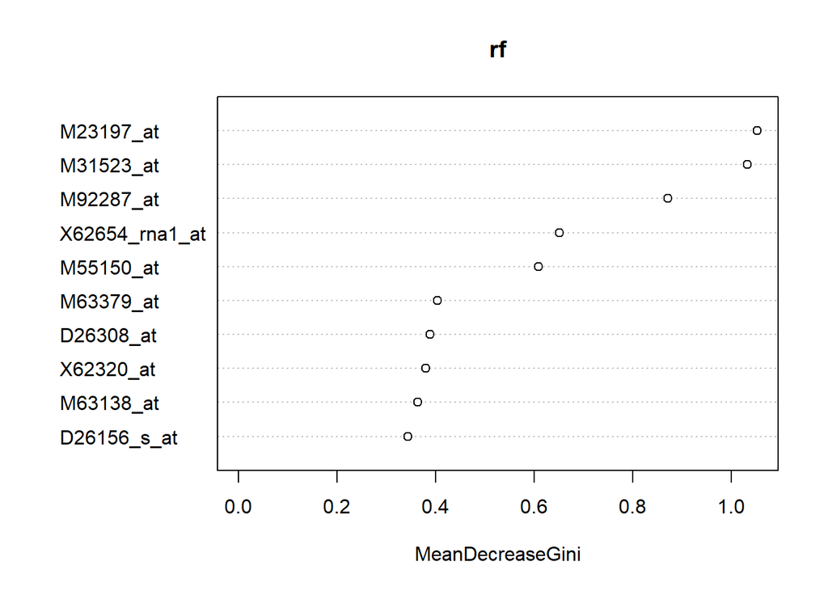

```r
var_imp376 = importance(rf)
#Conditional=True, adjusts for correlations between predictors.
varImpPlot(rf, n.var=10, conditional=TRUE)
```

```r
# 50
rf50 = randomForest(cls~., df50, ntree = 301)
rf50_pred = predict(rf50, df50)
rf50_tb = table(Predict =rf50_pred, Actual = df50$cls);rf50_tb
```

```
##        Actual
## Predict ALL AML
##     ALL  32   0
##     AML   0  18
```

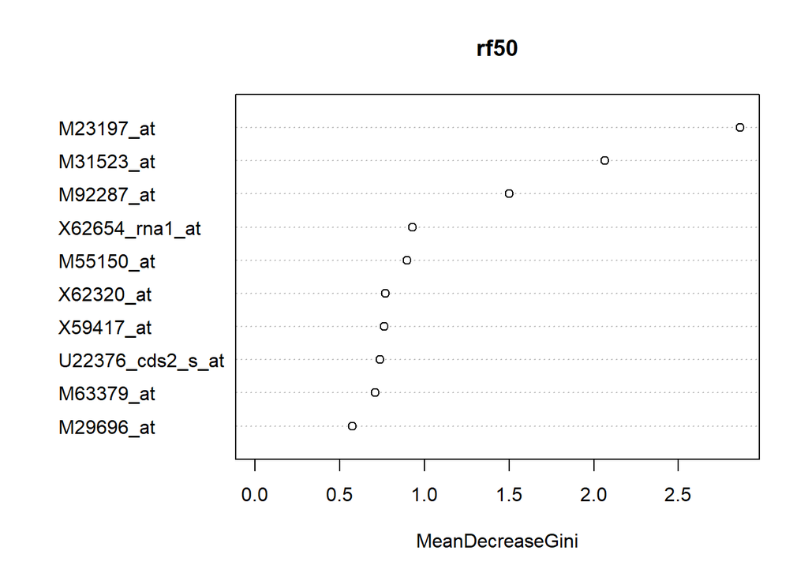

```r
var_imp50 = importance(rf50)
varImpPlot(rf50, n.var=10, conditional=TRUE) # showed top 10
```

```r
# 10
rf10 = randomForest(cls~., df10, ntree = 301)
rf10_pred = predict(rf10, df10)
rf10_tb = table(Predict =rf10_pred, Actual = df10$cls);rf10_tb
```

```
##        Actual
## Predict ALL AML
##     ALL  32   0
##     AML   0  18
```

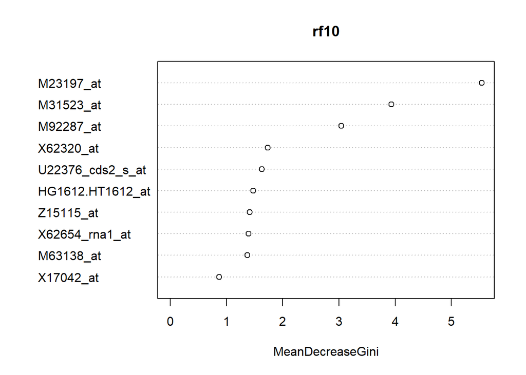

```r
varImpPlot(rf10, conditional=TRUE)
```

```r
# 6
rf6 = randomForest(cls~., df6, ntree = 301)
rf6_pred = predict(rf6, df6)
rf6_tb = table(Predict =rf6_pred, Actual = df6$cls);rf6_tb
```

```
##        Actual
## Predict ALL AML
##     ALL  32   0
##     AML   0  18
```

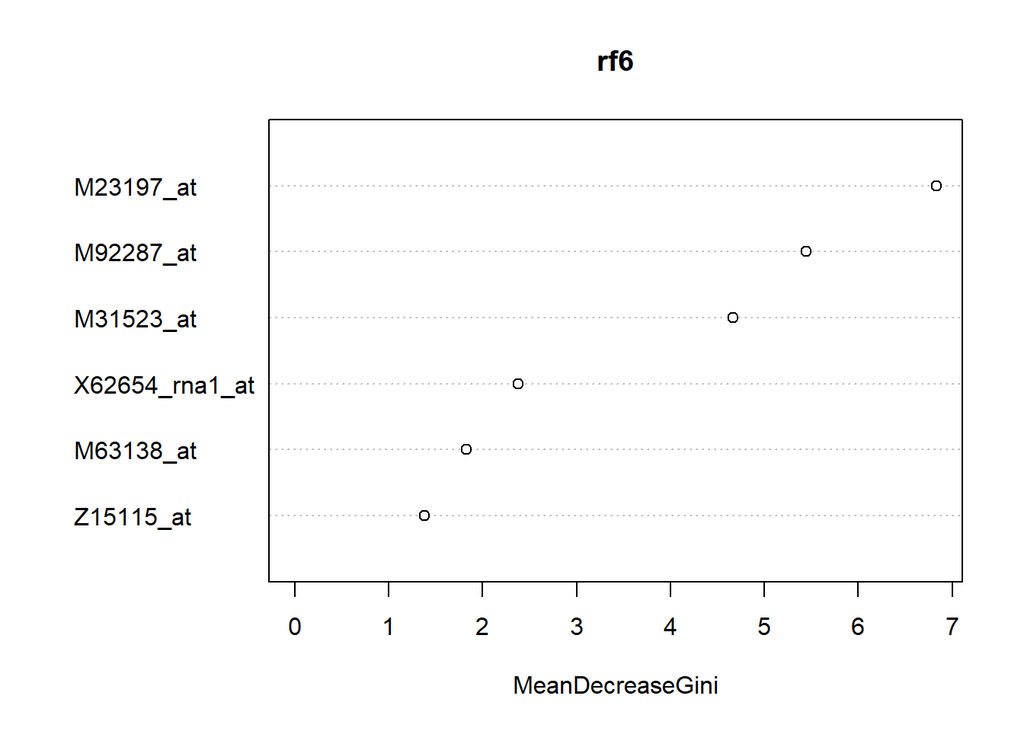

```r
varImpPlot(rf6, conditional=TRUE)
```

Note:  
Random Forest achieved 100% classification accuracy on the training set with 50, 10, and 6 features respectively.

### 5.3 Further attempts

```r
idx376_50 = head(order(var_imp376, decreasing = T), 50)
idx376_10 = idx376_50[1:10]
idx376_6  = idx376_50[1:6]

var376_50names = rownames(var_imp376)[idx376_50]
var376_10names = var376_50names[1:10]
var376_6names  = var376_50names[1:6]

commonIn50 = intersect(var376_50names, colnames(prep_train50))
length(commonIn50)
```

```
## [1] 34
```

```r
commonIn10 = intersect(var376_10names, colnames(prep_train10))
length(commonIn10)
```

```
## [1] 6
```

```r
commonIn6 = intersect(var376_6names, colnames(prep_train6))
length(commonIn6)
```

```
## [1] 4
```

The two algorithms picked features with 60-70% overlapped.  
The features with the “highest importance” are not necessarily the “most informative” ones.

# Step 6: Model Evaluation

### 6.1 Evaluation on the training set

We evaluate the training data using all viable algorithms selected in Step 5, comparing their performance through accuracy and confusion tables. Naturally, higher accuracy indicates better performance, but we also favor simpler models with strong predictive power.

### 6.2 Evaluation on the test set

We applied the same preprocessing steps on the test set based on the results from the training set: thresholding, filtering, log transformation and standardization. Then, we evaluated the model performance on the independent test set.

```r
vote_PS_cls(prep_test50, p_50, b50, golub_Ntest_r)
```

```
##            Actual
## Predict     ALL AML
##   ALL        12   0
##   AML         0   7
##   Uncertain   3   0
## [1] "The accuracy is: 0.864 with 50 features."
```

```r
vote_PS_cls(prep_test10, p_10, b10, golub_Ntest_r)
```

```
##        Actual
## Predict ALL AML
##     ALL  15   0
##     AML   0   7
## [1] "The accuracy is: 1 with 10 features."
```

```r
vote_PS_cls(prep_test6,  p_6,  b6,  golub_Ntest_r)
```

```
##        Actual
## Predict ALL AML
##     ALL  15   0
##     AML   0   7
## [1] "The accuracy is: 1 with 6 features."
```

```r
# 50
pred50_test = predict(nb50, prep_test50)
tble50_test = table(Predict = pred50_test, Actual = golub_Ntest_r);tble50_test
```

```
##        Actual
## Predict ALL AML
##     ALL  15   0
##     AML   0   7
```

```r
# 10
pred10_test = predict(nb10, prep_test10)
tble10_test = table(Predict = pred10_test, Actual = golub_Ntest_r);tble10_test
```

```
##        Actual
## Predict ALL AML
##     ALL  15   0
##     AML   0   7
```

```r
# 6
pred6_test = predict(nb6, prep_test6)
tble6_test = table(Predict = pred6_test, Actual = golub_Ntest_r);tble6_test
```

```
##        Actual
## Predict ALL AML
##     ALL  15   0
##     AML   0   7
```

Note:  
Naive Bayes achieved 100% classification accuracy on the test set with 50, 10, and 6 features respectively.

```r
# linear kernel ------------
# 50
svm50_pred_test = predict(svm50, df50_test)
svm_tb50_test = table(Predict = svm50_pred_test, Actual = df50_test$cls);svm_tb50_test
```

```
##        Actual
## Predict ALL AML
##     ALL  15   0
##     AML   0   7
```

```r
# 10
svm10_pred_test = predict(svm10, df10_test)
svm_tb10_test = table(Predict = svm10_pred_test, Actual = df10_test$cls);svm_tb10_test
```

```
##        Actual
## Predict ALL AML
##     ALL  15   0
##     AML   0   7
```

```r
# 6
svm6_pred_test = predict(svm6, df6_test)
svm_tb6_test = table(Predict = svm6_pred_test, Actual = df6_test$cls);svm_tb6_test
```

```
##        Actual
## Predict ALL AML
##     ALL  15   0
##     AML   0   7
```

```r
# quadratic kernel -------------
# 50
svmq50_pred_test = predict(svmq50, df50_test)
svmq_tb50_test = table(Predict = svmq50_pred_test, Actual = df50_test$cls);svmq_tb50_test
```

```
##        Actual
## Predict ALL AML
##     ALL  15   0
##     AML   0   7
```

```r
# 10
svmq10_pred_test = predict(svmq10, df10_test)
svmq_tb10_test = table(Predict = svmq10_pred_test, Actual = df10_test$cls);svmq_tb10_test
```

```
##        Actual
## Predict ALL AML
##     ALL  14   0
##     AML   1   7
```

```r
round(sum(diag(svmq_tb10_test))/sum(svmq_tb10_test),3)
```

```
## [1] 0.955
```

```r
# 6
svmq6_pred_test = predict(svmq6, df6_test)
svmq_tb6_test = table(Predict = svmq6_pred_test, Actual = df6_test$cls);svmq_tb6_test
```

```
##        Actual
## Predict ALL AML
##     ALL  14   0
##     AML   1   7
```

```r
round(sum(diag(svmq_tb6_test))/sum(svmq_tb6_test),3)
```

```
## [1] 0.955
```

SVM with quadratic kernel achieved 100%, 95.5% (21/22) and 95.5% classification accuracy on the test set with 50, 10, and 6 features respectively.

```r
# DLDA -50
dlda50_test_pred = predict(dlda50, df50_test, type="class")
dlda50_test_tb = table(Predict =dlda50_test_pred, Actual = df50_test$cls);dlda50_test_tb
```

```
##        Actual
## Predict ALL AML
##     ALL  15   0
##     AML   0   7
```

```r
# DLDA - 10
dlda10_test_pred = predict(dlda10, df10_test, type="class")
dlda10_test_tb = table(Predict =dlda10_test_pred, Actual = df10_test$cls);dlda10_test_tb
```

```
##        Actual
## Predict ALL AML
##     ALL  15   0
##     AML   0   7
```

```r
# DLDA - 6
dlda6_test_pred = predict(dlda6, df6_test, type="class")
dlda6_test_tb = table(Predict =dlda6_test_pred, Actual = df6_test$cls);dlda6_test_tb
```

```
##        Actual
## Predict ALL AML
##     ALL  15   0
##     AML   0   7
```

Note:  
Diagonal LDA achieved 100% classification accuracy on the test set with 50, 10, and 6 features respectively.

```r
# 50
rf50_pred_test = predict(rf50, df50_test)
rf50_tb_test = table(Predict=rf50_pred_test, Actual = df50_test$cls);rf50_tb_test
```

```
##        Actual
## Predict ALL AML
##     ALL  15   0
##     AML   0   7
```

```r
# 10
rf10_pred_test = predict(rf10, df10_test)
rf10_tb_test = table(Predict=rf10_pred_test, Actual = df10_test$cls);rf10_tb_test
```

```
##        Actual
## Predict ALL AML
##     ALL  15   0
##     AML   0   7
```

```r
# 6
rf6_pred_test = predict(rf6, df6_test)
rf6_tb_test = table(Predict=rf6_pred_test, Actual = df6_test$cls);rf6_tb_test
```

```
##        Actual
## Predict ALL AML
##     ALL  15   0
##     AML   0   7
```

Note:  
Random forest achieved 100% classification accuracy on the test set with 50, 10, and 6 features respectively.

# Step 7: Preservation

### 7.1 Perserve non-optimal implementations

We kept the code and model results when experimenting with different sets of predictors and various algorithms, as well as PCA and its relevant visualizations.

### 7.2 Register the code

One can “archive a GitHub repository in the Zenodo data repository” (Fenner 2018). An example for this work [here](https://github.com/Machine-Learning-Pipelines/IdealMachineLearningPipeline).

### 7.3 Data management plan

We followed the new Policy of National Institutes of Health (NIH) for Data Management and Sharing (Lippincott 2023):

### 7.3.1 Data products

Types of data generated:  
1, The data matrix of gene expressions after processing is 1821 predictors by 50 samples for the training set; 1821 predictors by 22 samples for the test set.

2, Confusion tables and accuracy accompanied by each model on training sets and test sets with three different sets of predictors.

### 7.3.2 Metadata

For example, the description of the covariate list, available in the golubEsets package (T. Golub 2023).

```r
Golub_Train@phenoData@varMetadata
```

```
##                                         labelDescription
## Samples                                     Sample index
## ALL.AML                    Factor, indicating ALL or AML
## BM.PB     Factor, sample from marrow or peripheral blood
## T.B.cell                  Factor, T cell or B cell leuk.
## FAB                           Factor, FAB classification
## Date                                Date sample obtained
## Gender                         Factor, gender of patient
## pctBlasts                   pct of cells that are blasts
## Treatment                          response to treatment
## PS                                   Prediction strength
## Source                                  Source of sample
```

### 7.3.3 Data Sharing & Archiving

The original data set are available in the package **golubEsets** by T. Golub (2023).  
The data after processing is available on [Zenodo](https://zenodo.org/record/8123245).

### 7.3.4 Data Licensing

LGPL (GNU Lesser General Public License) for the Golub data and the derived data in this paper (Stodden 2009).

### 7.4 Specify author contributions

List each researchers’ contribution to the paper, for example, according to [CRediT](https://credit.niso.org/) (Contributor Roles Taxonomy).

# Reference

Alwosheel, Ahmad, Sander van Cranenburgh, and Caspar G. Chorus. 2018. “Is Your Dataset Big Enough? Sample Size Requirements When Using Artificial Neural Networks for Discrete Choice Analysis.” *Journal of Choice Modelling* 28: 167–82. https://doi.org/10.1016/j.jocm.2018.07.002.

Barlett, James E., Joe W. Kotrlik, and Chadwick C. Higgins. 2001. “Organizational Research: Determining Appropriate Sample Size in Survey Research.” *Information Technology, Learning, and Performance Journal* 19 (1): 43–50.

“Cancer Stat Facts: Leukemia.” 2000. https://seer.cancer.gov/statfacts/html/leuks.html.

Dobbin, Kevin K., Yingdong Zhao, and Richard M. Simon. 2008. “How Large a Training Set Is Needed to Develop a Classifier for Microarray Data?” *Clinical Cancer Research* 14 (1): 108–14. https://doi.org/10.1158/1078-0432.ccr-07-0443.

Dudoit, Sandrine, Jane Fridlyand, and Terence P Speed. 2002. “Comparison of Discrimination Methods for the Classification of Tumors Using Gene Expression Data.” *Journal of the American Statistical Association* 97 (457): 77–87. https://doi.org/10.1198/016214502753479248.

Fenner, Martin. 2018. “Doi Registrations for Software.” *Front Matter*.

Gentleman, Robert. 2005. “Reproducible Research: A Bioinformatics Case Study.” *Statistical Applications in Genetics and Molecular Biology* 4 (1): Article2. https://doi.org/10.2202/1544-6115.1034.

Golub, T. R., D. K. Slonim, P. Tamayo, C. Huard, M. Gaasenbeek, J. P. Mesirov, H. Coller, et al. 1999. “Molecular Classification of Cancer: Class Discovery and Class Prediction by Gene Expression Monitoring.” *Science* 286 (5439): 531–37. https://doi.org/10.1126/science.286.5439.531.

Golub, Todd. 2023. *golubEsets: exprSets for Golub Leukemia Data*. https://doi.org/10.18129/B9.bioc.golubEsets.

Howley, Tom, Michael G Madden, Marie-Louise O’Connell, and Alan G Ryder. 2005. “The Effect of Principal Component Analysis on Machine Learning Accuracy with High Dimensional Spectral Data.” In *International Conference on Innovative Techniques and Applications of Artificial Intelligence*, 209–22. Springer.

Li, Leping, Clarice R. Weinberg, Thomas A. Darden, and Lee G. Pedersen. 2001. “Gene Selection for Sample Classification Based on Gene Expression Data: Study of Sensitivity to Choice of Parameters of the GA/KNN Method.” *Bioinformatics* 17 (12): 1131–42. https://doi.org/10.1093/bioinformatics/17.12.1131.

Lippincott, Sarah. 2023. “Dryad News,” July.

Mehrabi, Ninareh, Fred Morstatter, Nripsuta Saxena, Kristina Lerman, and Aram Galstyan. 2021. “A Survey on Bias and Fairness in Machine Learning.” *ACM Computing Surveys* 54 (6): 1–35. https://doi.org/10.1145/3457607.

Mukherjee, Sayan, Pablo Tamayo, Simon Rogers, Ryan Rifkin, Anna Engle, Colin Campbell, Todd R. Golub, and Jill P. Mesirov. 2003. “Estimating Dataset Size Requirements for Classifying DNA Microarray Data.” *Journal of Computational Biology* 10 (2): 119–42. https://doi.org/10.1089/106652703321825928.

Pappu, Vijay, and Panos M Pardalos. 2014. “Clusters, Orders, and Trees: Methods and Applications, in Honor of Boris Mirkin’s 70th Birthday.” *Springer Optimization and Its Applications*, 119–50. https://doi.org/10.1007/978-1-4939-0742-7_8.

Salah, Haneen T., Ibrahim N. Muhsen, Mohamed E. Salama, Tarek Owaidah, and Shahrukh K. Hashmi. 2019. “Machine Learning Applications in the Diagnosis of Leukemia: Current Trends and Future Directions.” *International Journal of Laboratory Hematology* 41 (6): 717–25. https://doi.org/10.1111/ijlh.13089.

Slonim, Donna K., Pablo Tamayo, Jill P. Mesirov, Todd R. Golub, and Eric S. Lander. 2000. “Class Prediction and Discovery Using Gene Expression Data.” *Proceedings of the Fourth Annual International Conference on Computational Molecular Biology*, 263–72. https://doi.org/10.1145/332306.332564.

Stodden, Victoria. 2009. “Enabling Reproducible Research: Open Licensing for Scientific Innovation.” *International Journal of Communications Law and Policy*, no. 13: 22–46. https://doi.org/10.1109/mcse.2009.19.

Stodden, Victoria, Xiaomian Wu, and Vanessa Sochat. 2018. “AIM: AN ABSTRACTION FOR IMPROVING MACHINE LEARNING PREDICTION.” *2018 IEEE Data Science Workshop (DSW)* 00: 1–5. https://doi.org/10.1109/dsw.2018.8439914.

Vayena, Effy, Alessandro Blasimme, and I. Glenn Cohen. 2018. “Machine Learning in Medicine: Addressing Ethical Challenges.” *PLoS Medicine* 15 (11): e1002689. https://doi.org/10.1371/journal.pmed.1002689.

Wang, Hong-Qiang, and De-Shuang Huang. 2006. “Regulation Probability Method for Gene Selection.” *Pattern Recognition Letters* 27 (2): 116–22. https://doi.org/10.1016/j.patrec.2005.07.007.

# Acknowledgment

Some of the code for Golub’s original experiment adapted from (Stodden, Wu, and Sochat 2018).